[O’Hara on GitHub](https://github.com/oharac)

# Figure 3: Comparing spp/FE and habitat impacts

Compiled on Mon Jul 25 18:33:32 2022 by ohara

```r
knitr::opts_chunk$set(echo = TRUE, message = FALSE, warning = FALSE, fig.height = 4, fig.width = 7)

library(terra)
library(sf)
library(oharac)
library(data.table)
library(tidyverse)
library(biscale)  ### for bivariate legend
library(cowplot)
library(showtext) ### for custom fonts
library(here)
source(here('common_fxns.R'))

font_add(family = 'bentonbold',
         regular = file.path('~/fonts',
                             'BentonSans Condensed Bold',
                             'BentonSans Condensed Bold.otf'))
font_add(family = 'benton',
         regular = file.path('~/fonts',
                             'BentonSans Condensed Book',
                             'BentonSans Condensed Book.otf'))
showtext_auto()
```

# 1 Summary

Create Fig. 3(?) for manuscript

# 2 Data

Results from scripts in folder `2_process_spp_vuln_and_impacts` and `3_process_hab_vuln_and_impacts`

# 3 Methods

NOTE: dropping cells with fewer than 20 species, mostly in the Arctic, a few in Antarctic.

```r
ocean_map <- rast(here('_spatial/ocean_area_mol.tif'))
ocean_df <- as.data.frame(ocean_map, xy = TRUE)

land_sf <- read_sf(here('_spatial/ne_10m_land/ne_10m_land_no_casp.shp')) %>%
  st_transform(st_crs(ocean_map))

nspp_mask <- rast(here('_output/nspp_maps/species_richness.tif'))
nspp_vals <- values(nspp_mask)
values(nspp_mask)[nspp_vals < 20] <- NA

chi_gps_hab <- list.files(here('_output/cumulative_impact_maps'),
                         pattern = 'habitat_group_chi',
                         full.names = TRUE)
chi_gps_fe <- list.files(here('_output/cumulative_impact_maps'),
                         pattern = 'funct_entity_group_chi',
                         full.names = TRUE)
climate_map_hab <- rast(chi_gps_hab[1]) %>%
  mask(nspp_mask)
climate_map_fe <- rast(chi_gps_fe[1]) %>%
  mask(nspp_mask)

nonclimate_map_hab <- rast(chi_gps_hab[2:4]) %>%
  sum(na.rm = TRUE) %>%
  mask(nspp_mask)

nonclimate_map_fe  <- rast(chi_gps_fe[2:4]) %>%
  sum(na.rm = TRUE) %>%
  mask(nspp_mask)
```

### 3.0.1 Reclassify

Reclassify values using `ntile` to get quartile values:

```r
cc_qtile_hab <- noncc_qtile_hab <- climate_map_hab ### initialize two new maps
values(cc_qtile_hab) <- ntile(values(climate_map_hab), 4)
values(noncc_qtile_hab) <- ntile(values(nonclimate_map_hab), 4)
# plot(cc_qtile_hab, axes = FALSE,
#      main = 'Climate impact quintile, habitat avg', col = hcl.colors(4))
# plot(noncc_qtile_hab, axes = FALSE,
#      main = 'Non-climate impact quintile, habitat avg', col = hcl.colors(4))
```

```r
cc_qtile_fe <- noncc_qtile_fe <- climate_map_fe ### initialize two new maps
values(cc_qtile_fe) <- ntile(values(climate_map_fe), 4)
values(noncc_qtile_fe) <- ntile(values(nonclimate_map_fe), 4)
# plot(cc_qtile_fe, axes = FALSE,
#      main = 'Climate impact quintile, fv wt avg', col = hcl.colors(4))
# plot(noncc_qtile_fe, axes = FALSE,
#      main = 'Non-climate impact quintile, fv wt avg', col = hcl.colors(4))
```

## 3.1 Create panels

### 3.1.1 Set up palettes

For the bivariate color plot, one axis of colors represents climate, the other represents non-climate; pull these values from the bivariate palette to use for the climate and non-climate maps separately.

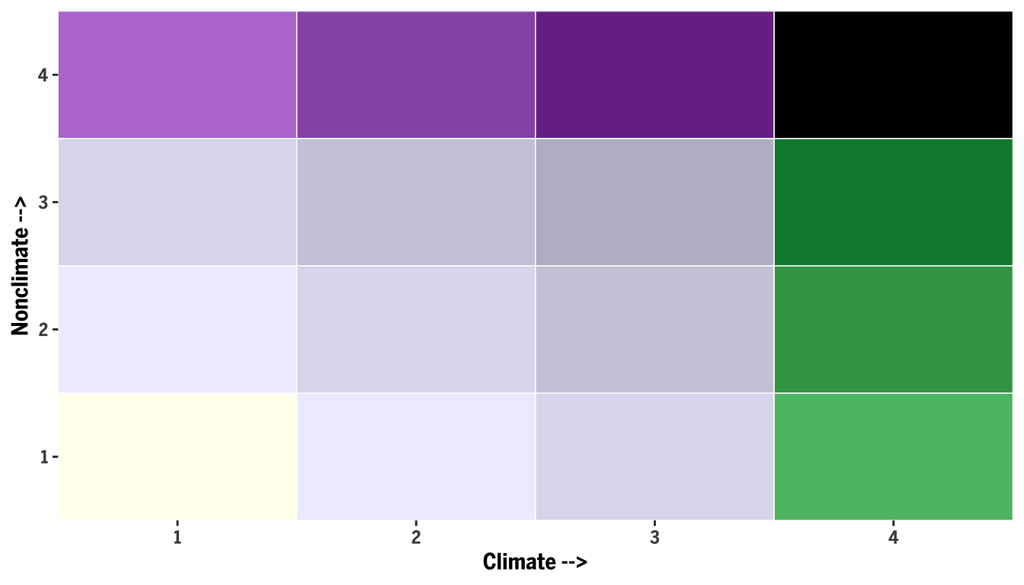

```r
div_clr <- c('#7b3294', '#008837', 'black')
### Diverging palettes from colorbrewer2.org:
#7b3294     #a6611a
#c2a5cf     #dfc27d
#f7f7f7     #f5f5f5
#a6dba0     #80cdc1
#008837     #018571

colors_df <- crossing(x = 1:4, y = 1:4) %>%
  mutate(bi_class = paste(x, y, sep = '-')) %>%
  mutate(bi_fill = case_when(bi_class == '1-1' ~ '#ffffee',
                             bi_class %in% c('1-2', '2-1') ~ '#eeeeff',
                             bi_class %in% c('1-3', '3-1', '2-2') ~ '#ddddee',
                             bi_class %in% c('2-3', '3-2') ~ '#ccccdd',
                             bi_class %in% c('3-3') ~ '#bbbbcc',
                             bi_class %in% c('1-4') ~ colorspace::lighten(div_clr[1], .4),
                             bi_class %in% c('2-4') ~ colorspace::lighten(div_clr[1], .2),
                             bi_class %in% c('3-4') ~ div_clr[1],
                             bi_class %in% c('4-1') ~ colorspace::lighten(div_clr[2], .4),
                             bi_class %in% c('4-2') ~ colorspace::lighten(div_clr[2], .2),
                             bi_class %in% c('4-3') ~ div_clr[2],
                             bi_class == '4-4' ~ div_clr[3], ### black
                             TRUE ~ 'blue'))

panel_a_lgd_raw <- ggplot(colors_df, aes(x, y, fill = bi_class)) +
  labs(x = "Climate -->",
       y = "Nonclimate -->") +
  geom_tile(show.legend = FALSE, color = 'white', size = .25) +
  scale_fill_manual(breaks = colors_df$bi_class, values = colors_df$bi_fill) +
  scale_x_continuous(expand = c(0, 0)) +
  scale_y_continuous(expand = c(0, 0)) +
  theme(text = element_text(family = 'bentonbold'),
        plot.background = element_blank())
panel_a_lgd_raw
```

### 3.1.2 Panel A: habitat average bivariate plot

Use a four-level bivariate color scale to capture spatial overlap of quartiles for climate and non-climate stressors.

```r
cc_hab_df <- as.data.frame(cc_qtile_hab, xy = TRUE) %>%
  setNames(c('x', 'y', 'cc_hab'))
noncc_hab_df <- as.data.frame(noncc_qtile_hab, xy = TRUE) %>%
  setNames(c('x', 'y', 'noncc_hab'))

cc_noncc_hab_df <- dt_join(cc_hab_df, noncc_hab_df, by = c('x', 'y'), type = 'full') %>%
  mutate(bi_class = paste(cc_hab, noncc_hab, sep = '-'))

### Polygon of hot-hot and cool-cool spots for outlines
# hot_cool_sf <- cc_noncc_hab_df %>%
#   filter(bi_class %in% c('1-1', '4-4')) %>%
#   mutate(val = ifelse(bi_class == '1-1', 0, 1)) %>%
#   select(x, y, val) %>%
#   rast(type = 'xyz', crs = crs(cc_qtile_hab)) %>%
#   as.polygons() %>%
#   sf::st_as_sf() %>%
#   st_simplify(dTolerance = 20000) %>%
#   mutate(val = as.character(val))

hab_overlap_summary <- cc_noncc_hab_df %>%
  group_by(bi_class) %>%
  summarize(ncell = n(),
            pct = n() / nrow(.))
knitr::kable(hab_overlap_summary, digits = 4,
             col.names = c('hab CHI overlap', '# of cells', '% of area'))
```

| hab CHI overlap | # of cells | % of area |
| --- | --- | --- |
| 1-1 | 183250 | 0.0512 |
| 1-2 | 334993 | 0.0935 |
| 1-3 | 195317 | 0.0545 |
| 1-4 | 181769 | 0.0508 |
| 2-1 | 180897 | 0.0505 |
| 2-2 | 264120 | 0.0737 |
| 2-3 | 259638 | 0.0725 |
| 2-4 | 190674 | 0.0532 |
| 3-1 | 236648 | 0.0661 |
| 3-2 | 203261 | 0.0568 |
| 3-3 | 233154 | 0.0651 |
| 3-4 | 222265 | 0.0621 |
| 4-1 | 294534 | 0.0822 |
| 4-2 | 92955 | 0.0260 |
| 4-3 | 207219 | 0.0579 |
| 4-4 | 300620 | 0.0839 |

```r
panel_a <- ggplot() +
  ### background for NA cells:
  geom_raster(data = ocean_df, aes(x, y), fill = 'grey85') +
  ### plot data:
  geom_raster(data = cc_noncc_hab_df, aes(x, y, fill = bi_class), show.legend = FALSE) +
  # bi_scale_fill(pal = pal_name, dim = 4) +
  scale_fill_manual(breaks = colors_df$bi_class, values = colors_df$bi_fill) +
  ### continents:
  geom_sf(data = land_sf,
          fill = 'grey96', color = 'grey40',
          size = .1) +
  # geom_sf(data = hot_cool_sf, aes(color = val),
  #         fill = NA, size = .1,
  #         show.legend = FALSE) +
  # scale_color_manual(values = c('green', 'yellow')) +
  scale_x_continuous(expand = c(0, 0)) +
  scale_y_continuous(expand = c(0, 0)) +
  theme_void() +
  theme(axis.text = element_blank(),
        axis.title = element_blank())
```

### 3.1.3 FE impact hot/cool spots overlap with hab impact

Compare the FE CHI hot/cool spots with hab - incl Sørensen similarity

```r
cc_fe_df <- as.data.frame(cc_qtile_fe, xy = TRUE) %>%
  setNames(c('x', 'y', 'cc_fe'))
noncc_fe_df <- as.data.frame(noncc_qtile_fe, xy = TRUE) %>%
  setNames(c('x', 'y', 'noncc_fe'))

cc_noncc_fe_df <- dt_join(cc_fe_df, noncc_fe_df,
                          by = c('x', 'y'), type = 'full') %>%
  mutate(bi_class = paste(cc_fe, noncc_fe, sep = '-'))

fe_hotspots <- cc_noncc_fe_df %>%
  filter(bi_class %in% c('1-1', '4-4')) %>%
  select(x, y, fe_bi = bi_class)
hab_hotspots <- cc_noncc_hab_df %>%
  filter(bi_class %in% c('1-1', '4-4')) %>%
  select(x, y, hab_bi = bi_class)

similarity_df <- fe_hotspots %>%
  full_join(hab_hotspots, by = c('x', 'y')) %>%
  mutate(match = case_when(is.na(hab_bi) ~ 'b',
                           is.na(fe_bi)  ~ 'c',
                           hab_bi == fe_bi ~ 'a',
                           TRUE ~ 'X')) %>%
  group_by(match) %>%
  summarize(n_gp = n()) %>%
  spread(match, n_gp) %>%
  mutate(jaccard = a / (a + b + c),
         sorensen = 2*a / (
           2*a + b + c))
knitr::kable(similarity_df)
```

| a | b | c | X | jaccard | sorensen |
| --- | --- | --- | --- | --- | --- |
| 217892 | 308989 | 265665 | 313 | 0.2749266 | 0.4312823 |

### 3.1.4 Panel B and C: hab-FE climate and non-climate overlap

```r
cc_fe_hab_df <- dt_join(cc_hab_df, cc_fe_df, by = c('x', 'y'), type = 'full') %>%
  mutate(bi_class = paste(cc_hab, cc_fe, sep = '-')) %>%
  filter(!is.na(cc_fe) & !is.na(cc_hab))

hab_overlap_summary <- cc_fe_hab_df %>%
  group_by(bi_class) %>%
  summarize(ncell = n(),
            pct = n() / nrow(.))
knitr::kable(hab_overlap_summary, digits = 4,
             col.names = c('hab/FE CHI overlap, climate', '# of cells', '% of area'))
```

| hab/FE CHI overlap, climate | # of cells | % of area |
| --- | --- | --- |
| 1-1 | 527278 | 0.1472 |
| 1-2 | 159146 | 0.0444 |
| 1-3 | 72054 | 0.0201 |
| 1-4 | 136851 | 0.0382 |
| 2-1 | 258947 | 0.0723 |
| 2-2 | 300133 | 0.0838 |
| 2-3 | 176773 | 0.0494 |
| 2-4 | 159476 | 0.0445 |
| 3-1 | 90633 | 0.0253 |
| 3-2 | 285520 | 0.0797 |
| 3-3 | 317493 | 0.0887 |
| 3-4 | 201682 | 0.0563 |
| 4-1 | 19534 | 0.0055 |
| 4-2 | 151350 | 0.0423 |
| 4-3 | 329602 | 0.0920 |
| 4-4 | 394842 | 0.1103 |

```r
panel_b <- ggplot() +
  ### background for NA cells:
  geom_raster(data = ocean_df, aes(x, y), fill = 'grey85') +
  ### plot data:
  geom_raster(data = cc_fe_hab_df, aes(x, y, fill = bi_class), show.legend = FALSE) +
  scale_fill_manual(breaks = colors_df$bi_class, values = colors_df$bi_fill) +
  ### continents:
  geom_sf(data = land_sf,
          fill = 'grey96', color = 'grey40',
          size = .1) +
  scale_x_continuous(expand = c(0, 0)) +
  scale_y_continuous(expand = c(0, 0)) +
  theme_void() +
  theme(axis.text = element_blank(),
        axis.title = element_blank())
```

```r
noncc_fe_hab_df <- dt_join(noncc_hab_df, noncc_fe_df, by = c('x', 'y'), type = 'full') %>%
  mutate(bi_class = paste(noncc_hab, noncc_fe, sep = '-')) %>%
  filter(!is.na(noncc_fe) & !is.na(noncc_hab))

hab_overlap_summary <- noncc_fe_hab_df %>%
  group_by(bi_class) %>%
  summarize(ncell = n(),
            pct = n() / nrow(.))
knitr::kable(hab_overlap_summary, digits = 4,
             col.names = c('hab/FE CHI overlap, nonclimate', '# of cells', '% of area'))
```

| hab/FE CHI overlap, nonclimate | # of cells | % of area |
| --- | --- | --- |
| 1-1 | 799382 | 0.2232 |
| 1-2 | 54996 | 0.0154 |
| 1-3 | 22328 | 0.0062 |
| 1-4 | 18623 | 0.0052 |
| 2-1 | 95363 | 0.0266 |
| 2-2 | 643232 | 0.1796 |
| 2-3 | 122969 | 0.0343 |
| 2-4 | 33765 | 0.0094 |
| 3-1 | 947 | 0.0003 |
| 3-2 | 197063 | 0.0550 |
| 3-3 | 562122 | 0.1570 |
| 3-4 | 135196 | 0.0378 |
| 4-1 | 283 | 0.0001 |
| 4-2 | 1261 | 0.0004 |
| 4-3 | 188812 | 0.0527 |
| 4-4 | 704972 | 0.1968 |

```r
panel_c <- ggplot() +
  ### background for NA cells:
  geom_raster(data = ocean_df, aes(x, y), fill = 'grey85') +
  ### plot data:
  geom_raster(data = noncc_fe_hab_df, aes(x, y, fill = bi_class), show.legend = FALSE) +
  scale_fill_manual(breaks = colors_df$bi_class, values = colors_df$bi_fill) +
  ### continents:
  geom_sf(data = land_sf,
          fill = 'grey96', color = 'grey40',
          size = .1) +
  scale_x_continuous(expand = c(0, 0)) +
  scale_y_continuous(expand = c(0, 0)) +
  theme_void() +
  theme(axis.text = element_blank(),
        axis.title = element_blank())
```

```r
panel_bc_lgd_raw <- ggplot(colors_df, aes(x, y, fill = bi_class)) +
  labs(x = "CHI Hab -->",
       y = "CHI FE -->") +
  geom_tile(show.legend = FALSE, color = 'white', size = .25) +
  scale_fill_manual(breaks = colors_df$bi_class, values = colors_df$bi_fill) +
  scale_x_continuous(expand = c(0, 0)) +
  scale_y_continuous(expand = c(0, 0)) +
  theme(text = element_text(family = 'bentonbold'),
        plot.background = element_blank())
# panel_bc_lgd_raw
```

## 3.2 Assemble figure

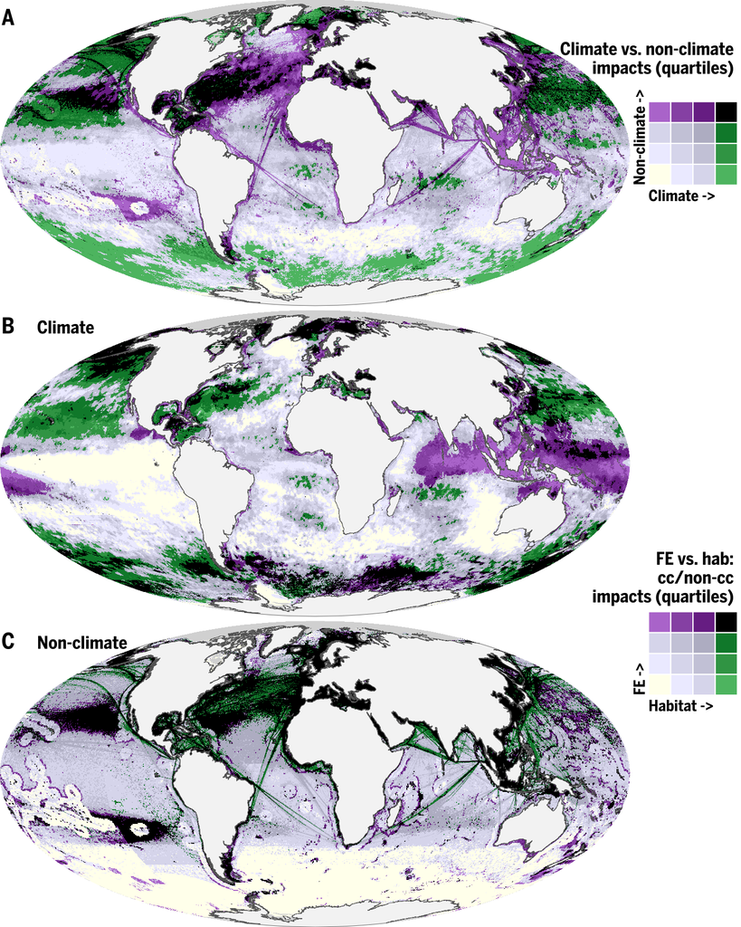

```r
fig3_file <- here('5_ms_figs/fig3_comparing_hab_vs_fe_chi.png')
panel_a_map  <- get_panel(panel_a)
panel_b_map  <- get_panel(panel_b)
panel_c_map  <- get_panel(panel_c)
# panel_d_map  <- get_panel(panel_d)
panel_a_lgd <- get_panel(panel_a_lgd_raw)
panel_bc_lgd <- get_panel(panel_bc_lgd_raw)

### parameterize legends for easier changing of label positions:
lgd_a_xy <- c(x = .875, y = .80, h = .09, w = .12)
lgd_b_xy <- c(x = .875, y = .25, h = .09, w = .12)

fig_3 <- ggdraw() +
  ### draw panels:
  draw_plot(panel_a_map,  x = 0.00, y = 0.67, height = 0.33, width = 0.85) +
  draw_plot(panel_b_map,  x = 0.00, y = 0.335, height = 0.33, width = 0.85) +
  draw_plot(panel_c_map,  x = 0.00, y = 0.00, height = 0.33, width = 0.85) +
  ### draw legends:
  draw_plot(panel_a_lgd, x = lgd_a_xy['x'], y = lgd_a_xy['y'],
            height = lgd_a_xy['h'], width = lgd_a_xy['w']) +
  draw_plot(panel_bc_lgd, x = lgd_b_xy['x'], y = lgd_b_xy['y'],
            height = lgd_b_xy['h'], width = lgd_b_xy['w']) +
  ### Panel labels:
  draw_label('A', x = 0.002, y = .99, hjust = 0, vjust = 1,
             size = 10, fontfamily = 'bentonbold') +
  draw_label('B', x = 0.002, y = .64, hjust = 0, vjust = 0,
             size = 10, fontfamily = 'bentonbold') +
  draw_label('C', x = 0.002, y = .30, hjust = 0, vjust = 0,
             size = 10, fontfamily = 'bentonbold') +
  draw_label('Climate', x = 0.05, y = .64, hjust = 0, vjust = 0,
             size = 8, fontfamily = 'bentonbold') +
  draw_label('Non-climate', x = 0.05, y = .30, hjust = 0, vjust = 0,
             size = 8, fontfamily = 'bentonbold') +
  ### panel A labels:
  draw_label('Climate vs. non-climate\nimpacts (quartiles)',
             x = 0.99, y = 0.92, hjust = 1, vjust = 0, angle = 0,
             size = 8, color = 'black', fontfamily = 'bentonbold') +
  draw_label('Climate ->',
             x = lgd_a_xy['x'], y = lgd_a_xy['y'] - .005,
             hjust = 0, vjust = 1, angle = 0,
             size = 7, color = 'black', fontfamily = 'bentonbold') +
  draw_label('Non-climate ->',
             x = lgd_a_xy['x'] - .005, y = lgd_a_xy['y'],
             hjust = 0, vjust = 0, angle = 90,
             size = 7, color = 'black', fontfamily = 'bentonbold') +
  ### panel B & C labels:
  draw_label('FE vs. hab:\ncc/non-cc\nimpacts (quartiles)',
             x = 0.99, y = 0.35, hjust = 1, vjust = 0, angle = 0,
             size = 8, color = 'black', fontfamily = 'bentonbold') +
  draw_label('Habitat ->',
             x = lgd_b_xy['x'], y = lgd_b_xy['y'] - .005,
             hjust = 0, vjust = 1, angle = 0,
             size = 7, color = 'black', fontfamily = 'bentonbold') +
  draw_label('FE ->',
             x = lgd_b_xy['x'] - .005, y = lgd_b_xy['y'],
             hjust = 0, vjust = 0, angle = 90,
             size = 7, color = 'black', fontfamily = 'bentonbold')

ggsave(fig3_file, width = 12, height = 15, units = 'cm', dpi = 300)

knitr::include_graphics(fig3_file)
```